# Week 5 results

## Useful links

### Video

Dimension reduction and PCA:

http://player.vimeo.com/video/204164956

Biplots:

http://player.vimeo.com/video/204165420

MCA:

http://player.vimeo.com/video/204251158

### Slides

The presentation slides related to the videos above are here: https://tuomonieminen.github.io/Helsinki-Open-Data-Science/#/54

### Other links

Some useful links related to this weeks topics:

PCA explained visually http://setosa.io/ev/principal-component-analysis/ Mathematical tutorial on PCA https://arxiv.org/pdf/1404.1100.pdf Biplots in practise (e-book by Michael Greenacre) http://www.multivariatestatistics.org/biplots.html Correspondence analysis - general purpose https://documents.software.dell.com/statistics/textbook/correspondence-analysis#general The FactoMineR webpage http://factominer.free.fr/

## Data analysis

### Data wrangling

Link to data wrangling part (R script) https://github.com/salopant/IODS-project/blob/master/data/human.R

### Data described

The featues in the data are + Country - Country name, id of the row + Edu2F - Education rate of female  
+ LabFM - Labour force participation rate of both genders + LifeEx - Life expectancy at birth, years + ExpEduYrs - Expected years of schooling + GNI - Gross national income (GNI) per capita + MaternMortR - Maternal mortar rate + AdoBirthR - Births per 1000 women ages 15 - 19 + PctReprParl - Women share of seats in parliament

```r
library(dplyr)
```

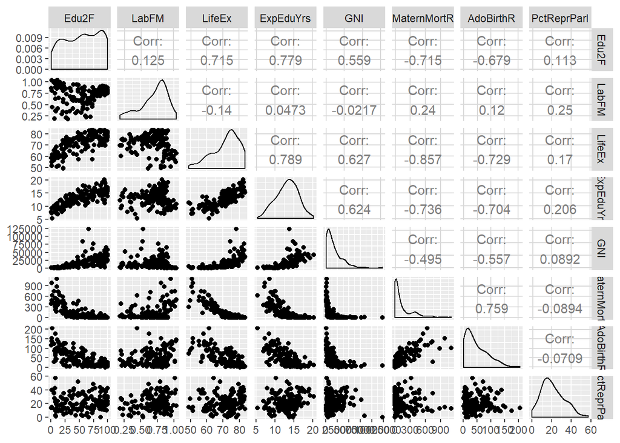

```r
library(corrplot)
human <- read.csv("./data/human_mod.csv", row.names = 1)
# Access GGally
library(GGally)
# visualize the 'human_' variables
ggpairs(human)
```

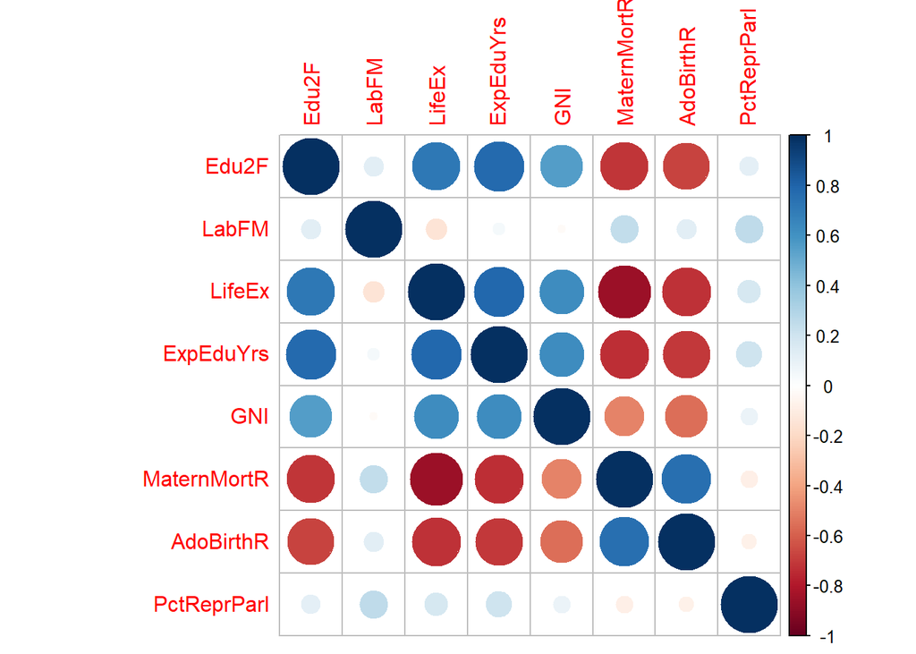

```r
# compute the correlation matrix and visualize it with corrplot
cor(human) %>% corrplot()
```

### PCA

#### Non scaled data

Next perform principal component analysis on the data:

```r
# modified human is available
library(stats)

# print out summaries of the standardized variables
summary(human)
```

```
##      Edu2F            LabFM            LifeEx        ExpEduYrs
##  Min.   :  0.90   Min.   :0.1857   Min.   :49.00   Min.   : 5.40
##  1st Qu.: 27.15   1st Qu.:0.5984   1st Qu.:66.30   1st Qu.:11.25
##  Median : 56.60   Median :0.7535   Median :74.20   Median :13.50
##  Mean   : 55.37   Mean   :0.7074   Mean   :71.65   Mean   :13.18
##  3rd Qu.: 85.15   3rd Qu.:0.8535   3rd Qu.:77.25   3rd Qu.:15.20
##  Max.   :100.00   Max.   :1.0380   Max.   :83.50   Max.   :20.20
##       GNI          MaternMortR       AdoBirthR       PctReprParl
##  Min.   :   581   Min.   :   1.0   Min.   :  0.60   Min.   : 0.00
##  1st Qu.:  4198   1st Qu.:  11.5   1st Qu.: 12.65   1st Qu.:12.40
##  Median : 12040   Median :  49.0   Median : 33.60   Median :19.30
##  Mean   : 17628   Mean   : 149.1   Mean   : 47.16   Mean   :20.91
##  3rd Qu.: 24512   3rd Qu.: 190.0   3rd Qu.: 71.95   3rd Qu.:27.95
##  Max.   :123124   Max.   :1100.0   Max.   :204.80   Max.   :57.50
```

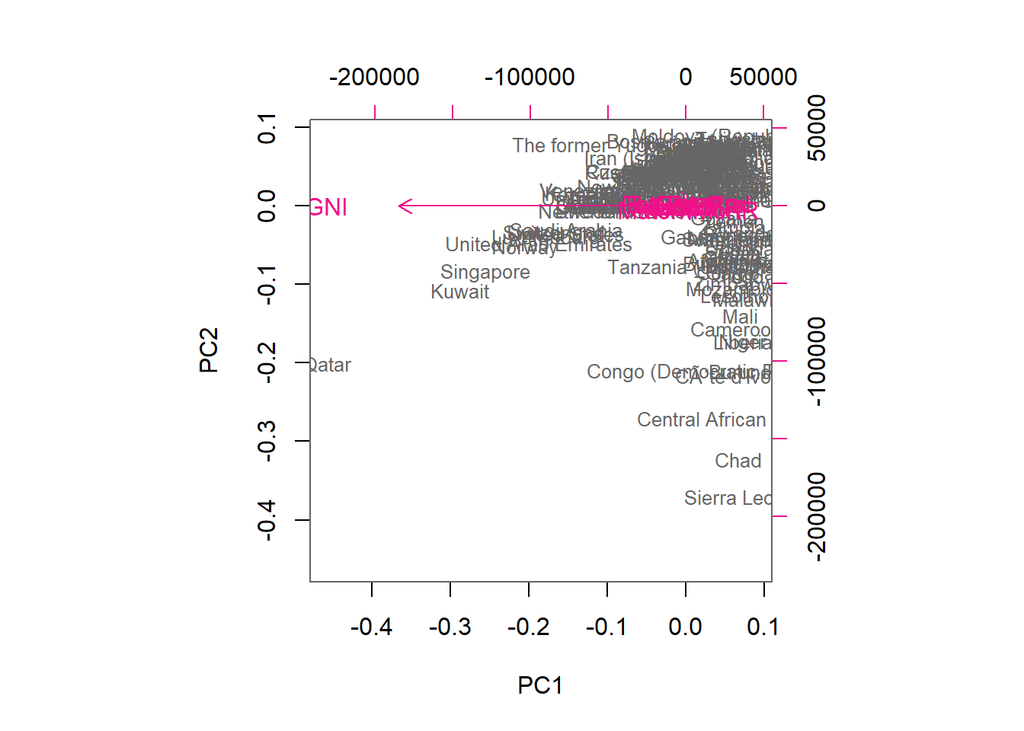

```r
# perform principal component analysis (with the SVD method)
pca_human <- prcomp(human)

# draw a biplot of the principal component representation and the original variables
biplot(pca_human, choices = 1:2, cex = c(0.8, 1), col=c("grey40", "deeppink2"))
```

Now, perform the same PCA on *normalized* data

```r
# modified human is available
library(stats)
# standardize the variables
human_std <- scale(human)

# print out summaries of the standardized variables
summary(human_std)
```

```
##      Edu2F              LabFM             LifeEx          ExpEduYrs
##  Min.   :-1.76122   Min.   :-2.6247   Min.   :-2.7188   Min.   :-2.7378
##  1st Qu.:-0.91250   1st Qu.:-0.5484   1st Qu.:-0.6425   1st Qu.:-0.6782
##  Median : 0.03967   Median : 0.2316   Median : 0.3056   Median : 0.1140
##  Mean   : 0.00000   Mean   : 0.0000   Mean   : 0.0000   Mean   : 0.0000
##  3rd Qu.: 0.96275   3rd Qu.: 0.7350   3rd Qu.: 0.6717   3rd Qu.: 0.7126
##  Max.   : 1.44288   Max.   : 1.6632   Max.   : 1.4218   Max.   : 2.4730
##       GNI           MaternMortR        AdoBirthR        PctReprParl
##  Min.   :-0.9193   Min.   :-0.6992   Min.   :-1.1325   Min.   :-1.8203
##  1st Qu.:-0.7243   1st Qu.:-0.6496   1st Qu.:-0.8394   1st Qu.:-0.7409
##  Median :-0.3013   Median :-0.4726   Median :-0.3298   Median :-0.1403
##  Mean   : 0.0000   Mean   : 0.0000   Mean   : 0.0000   Mean   : 0.0000
##  3rd Qu.: 0.3712   3rd Qu.: 0.1932   3rd Qu.: 0.6030   3rd Qu.: 0.6127
##  Max.   : 5.6890   Max.   : 4.4899   Max.   : 3.8344   Max.   : 3.1850
```

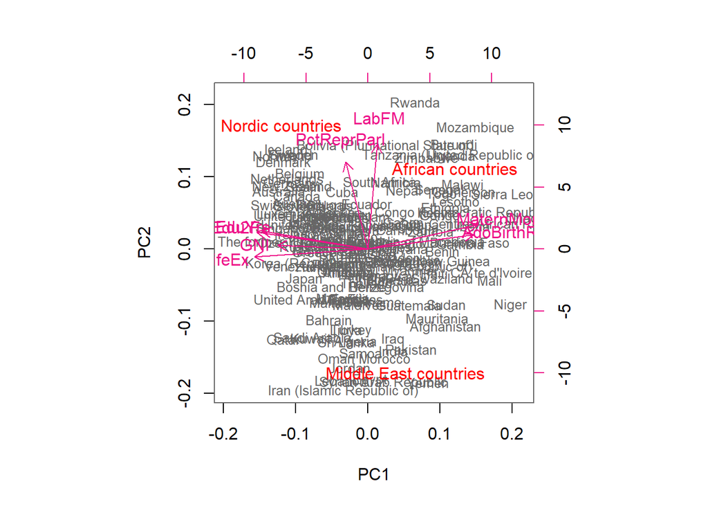

```r
# perform principal component analysis (with the SVD method)
pca_human_std <- prcomp(human_std)

# draw a biplot of the principal component representation and the original variables
biplot(pca_human_std, choices = 1:2, cex = c(0.8, 1), col=c("grey40", "deeppink2"))

text(-7,10,"Nordic countries",col = "red")
text(3,-10,"Middle East countries",col = "red")
text(7,6.5,"African countries",col = "red")
```

Now the biplot of the analysis shows that really all other variables than LabFM and PctReprParl are closely aligned in direction of the first principal component implying that they do correlate and that they also explain most of the variance in the data. On the other hand the two named variables are almost parallel with the second PC. This figure makes a lot of sense when interpreted with the correlation plot.